# Risk Factor Analysis

## Outcome Variable

**Outcome Variable:** ever_wasted

## Predictor Variables

**Intervention Variable:** nhh

**Adjustment Set:**

- arm
- W_mage
- meducyrs
- feducyrs
- W_mhtcm
- W_mwtkg
- W_mbmi
- W_nrooms
- impfloor
- impsan
- safeh20
- delta_W_mage
- delta_meducyrs
- delta_feducyrs
- delta_W_mhtcm
- delta_W_mwtkg
- delta_W_mbmi
- delta_W_nrooms
- delta_impfloor
- delta_impsan
- delta_safeh20

## Stratifying Variables

The analysis was stratified on these variable(s):

- agecat
- studyid
- country

## Data Summary

| agecat | studyid | country | nhh | ever_wasted | n_cell | n |
| --- | --- | --- | --- | --- | --- | --- |
| 0-24 months | IRC | INDIA | 3 or less | 0 | 20 | 410 |
| 0-24 months | IRC | INDIA | 3 or less | 1 | 38 | 410 |
| 0-24 months | IRC | INDIA | 4-5 | 0 | 63 | 410 |
| 0-24 months | IRC | INDIA | 4-5 | 1 | 95 | 410 |
| 0-24 months | IRC | INDIA | 6-7 | 0 | 38 | 410 |
| 0-24 months | IRC | INDIA | 6-7 | 1 | 69 | 410 |
| 0-24 months | IRC | INDIA | 8+ | 0 | 20 | 410 |
| 0-24 months | IRC | INDIA | 8+ | 1 | 67 | 410 |
| 0-24 months | LCNI-5 | MALAWI | 3 or less | 0 | 210 | 817 |
| 0-24 months | LCNI-5 | MALAWI | 3 or less | 1 | 15 | 817 |
| 0-24 months | LCNI-5 | MALAWI | 4-5 | 0 | 310 | 817 |
| 0-24 months | LCNI-5 | MALAWI | 4-5 | 1 | 30 | 817 |
| 0-24 months | LCNI-5 | MALAWI | 6-7 | 0 | 172 | 817 |
| 0-24 months | LCNI-5 | MALAWI | 6-7 | 1 | 10 | 817 |
| 0-24 months | LCNI-5 | MALAWI | 8+ | 0 | 59 | 817 |
| 0-24 months | LCNI-5 | MALAWI | 8+ | 1 | 11 | 817 |
| 0-24 months | NIH-Birth | BANGLADESH | 3 or less | 0 | 58 | 624 |
| 0-24 months | NIH-Birth | BANGLADESH | 3 or less | 1 | 57 | 624 |
| 0-24 months | NIH-Birth | BANGLADESH | 4-5 | 0 | 134 | 624 |
| 0-24 months | NIH-Birth | BANGLADESH | 4-5 | 1 | 129 | 624 |
| 0-24 months | NIH-Birth | BANGLADESH | 6-7 | 0 | 72 | 624 |
| 0-24 months | NIH-Birth | BANGLADESH | 6-7 | 1 | 69 | 624 |
| 0-24 months | NIH-Birth | BANGLADESH | 8+ | 0 | 62 | 624 |
| 0-24 months | NIH-Birth | BANGLADESH | 8+ | 1 | 43 | 624 |
| 0-24 months | NIH-Crypto | BANGLADESH | 3 or less | 0 | 75 | 758 |
| 0-24 months | NIH-Crypto | BANGLADESH | 3 or less | 1 | 39 | 758 |
| 0-24 months | NIH-Crypto | BANGLADESH | 4-5 | 0 | 224 | 758 |
| 0-24 months | NIH-Crypto | BANGLADESH | 4-5 | 1 | 118 | 758 |
| 0-24 months | NIH-Crypto | BANGLADESH | 6-7 | 0 | 120 | 758 |
| 0-24 months | NIH-Crypto | BANGLADESH | 6-7 | 1 | 58 | 758 |

[output cut: 114 more lines]

The following strata were considered:

- agecat: 0-24 months, studyid: IRC, country: INDIA
- agecat: 0-24 months, studyid: LCNI-5, country: MALAWI
- agecat: 0-24 months, studyid: NIH-Birth, country: BANGLADESH
- agecat: 0-24 months, studyid: NIH-Crypto, country: BANGLADESH
- agecat: 0-24 months, studyid: PROVIDE, country: BANGLADESH
- agecat: 0-24 months, studyid: SAS-FoodSuppl, country: INDIA
- agecat: 0-6 months, studyid: IRC, country: INDIA
- agecat: 0-6 months, studyid: LCNI-5, country: MALAWI
- agecat: 0-6 months, studyid: NIH-Birth, country: BANGLADESH
- agecat: 0-6 months, studyid: NIH-Crypto, country: BANGLADESH
- agecat: 0-6 months, studyid: PROVIDE, country: BANGLADESH
- agecat: 0-6 months, studyid: SAS-FoodSuppl, country: INDIA
- agecat: 6-24 months, studyid: IRC, country: INDIA
- agecat: 6-24 months, studyid: LCNI-5, country: MALAWI
- agecat: 6-24 months, studyid: NIH-Birth, country: BANGLADESH
- agecat: 6-24 months, studyid: NIH-Crypto, country: BANGLADESH
- agecat: 6-24 months, studyid: PROVIDE, country: BANGLADESH
- agecat: 6-24 months, studyid: SAS-FoodSuppl, country: INDIA

### Dropped Strata

Some strata were dropped due to rare outcomes:

- agecat: 0-6 months, studyid: LCNI-5, country: MALAWI
- agecat: 0-6 months, studyid: SAS-FoodSuppl, country: INDIA

## Methods Detail

We're interested in the causal parameters $E[Y_a]$ for all values of $a \in \mathcal{A}$. These parameters represent the mean outcome if, possibly contrary to fact, we intervened to set all units to have $A=a$. Under the randomization and positivity assumptions, these are identified by the statistical parameters $\psi_a=E_W[E_{Y|A,W}(Y|A=a,W)]$. In addition, we're interested in the mean of $Y$, $E[Y]$ under no intervention (the observed mean). We will estimate these parameters by using SuperLearner to fit the relevant likelihood factors -- $E_{Y|A,W}(Y|A=a,W)$ and $p(A=a|W)$, and then updating our likelihood fit using a joint TMLE.

For unadjusted analyses ($W=\{\}$), initial likelihoods were estimated using Lrnr_glm to estimate the simple $E(Y|A)$ and Lrnr_mean to estimate $p(A)$. For adjusted analyses, a small library containing Lrnr_glmnet, Lrnr_xgboost, and Lrnr_mean was used.

Having estimated these parameters, we will then use the delta method to estimate relative risks and attributable risks relative to a prespecified baseline level of $A$.

# Results Detail

## Results Plots

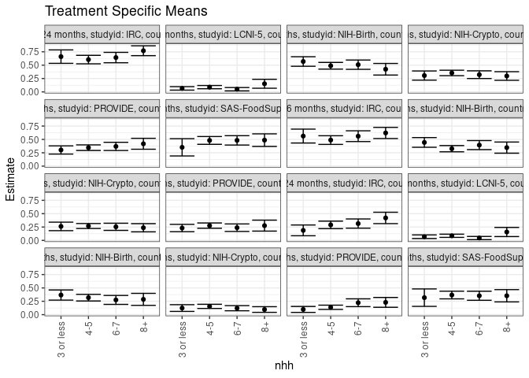

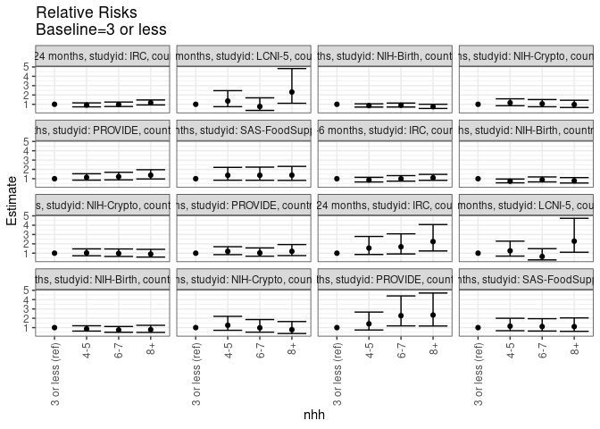

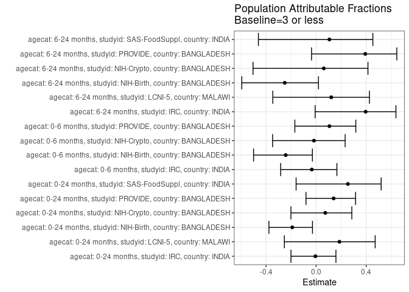

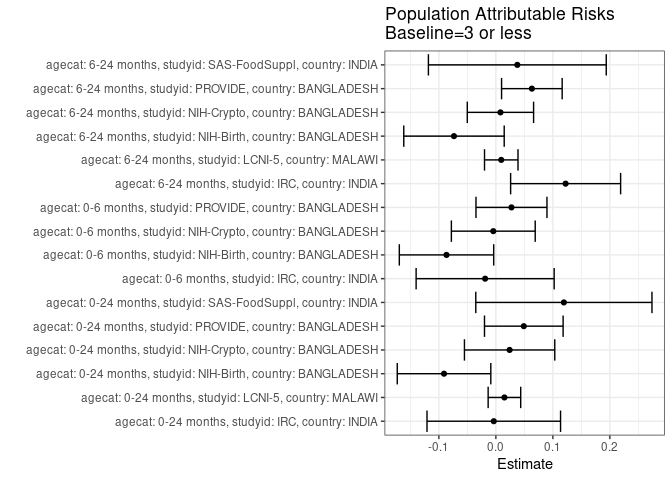

## Results Table

### Parameter: TSM

| agecat | studyid | country | intervention_level | baseline_level | estimate | ci_lower | ci_upper |
| --- | --- | --- | --- | --- | --- | --- | --- |
| 0-24 months | IRC | INDIA | 3 or less | NA | 0.6597659 | 0.5339894 | 0.7855425 |
| 0-24 months | IRC | INDIA | 4-5 | NA | 0.6043994 | 0.5249539 | 0.6838448 |
| 0-24 months | IRC | INDIA | 6-7 | NA | 0.6422032 | 0.5449810 | 0.7394254 |
| 0-24 months | IRC | INDIA | 8+ | NA | 0.7699253 | 0.6779375 | 0.8619131 |
| 0-24 months | LCNI-5 | MALAWI | 3 or less | NA | 0.0657670 | 0.0334431 | 0.0980909 |
| 0-24 months | LCNI-5 | MALAWI | 4-5 | NA | 0.0890488 | 0.0586941 | 0.1194035 |
| 0-24 months | LCNI-5 | MALAWI | 6-7 | NA | 0.0502426 | 0.0188818 | 0.0816033 |
| 0-24 months | LCNI-5 | MALAWI | 8+ | NA | 0.1520599 | 0.0683950 | 0.2357248 |
| 0-24 months | NIH-Birth | BANGLADESH | 3 or less | NA | 0.5685085 | 0.4793458 | 0.6576713 |
| 0-24 months | NIH-Birth | BANGLADESH | 4-5 | NA | 0.4886021 | 0.4261139 | 0.5510904 |
| 0-24 months | NIH-Birth | BANGLADESH | 6-7 | NA | 0.5089808 | 0.4217553 | 0.5962063 |
| 0-24 months | NIH-Birth | BANGLADESH | 8+ | NA | 0.4237473 | 0.3152714 | 0.5322231 |
| 0-24 months | NIH-Crypto | BANGLADESH | 3 or less | NA | 0.3057101 | 0.2199569 | 0.3914634 |
| 0-24 months | NIH-Crypto | BANGLADESH | 4-5 | NA | 0.3541602 | 0.3032167 | 0.4051037 |
| 0-24 months | NIH-Crypto | BANGLADESH | 6-7 | NA | 0.3220877 | 0.2501388 | 0.3940366 |
| 0-24 months | NIH-Crypto | BANGLADESH | 8+ | NA | 0.2975104 | 0.2168475 | 0.3781734 |
| 0-24 months | PROVIDE | BANGLADESH | 3 or less | NA | 0.3024131 | 0.2259024 | 0.3789238 |
| 0-24 months | PROVIDE | BANGLADESH | 4-5 | NA | 0.3456254 | 0.2933712 | 0.3978796 |
| 0-24 months | PROVIDE | BANGLADESH | 6-7 | NA | 0.3693452 | 0.2926707 | 0.4460198 |
| 0-24 months | PROVIDE | BANGLADESH | 8+ | NA | 0.4182722 | 0.3161758 | 0.5203686 |
| 0-24 months | SAS-FoodSuppl | INDIA | 3 or less | NA | 0.3519633 | 0.1904815 | 0.5134451 |
| 0-24 months | SAS-FoodSuppl | INDIA | 4-5 | NA | 0.4811369 | 0.4082289 | 0.5540448 |
| 0-24 months | SAS-FoodSuppl | INDIA | 6-7 | NA | 0.4821353 | 0.3947209 | 0.5695497 |
| 0-24 months | SAS-FoodSuppl | INDIA | 8+ | NA | 0.4866352 | 0.3690428 | 0.6042276 |
| 0-6 months | IRC | INDIA | 3 or less | NA | 0.5627288 | 0.4328053 | 0.6926523 |
| 0-6 months | IRC | INDIA | 4-5 | NA | 0.4878666 | 0.4070125 | 0.5687207 |
| 0-6 months | IRC | INDIA | 6-7 | NA | 0.5605257 | 0.4598864 | 0.6611649 |
| 0-6 months | IRC | INDIA | 8+ | NA | 0.6209545 | 0.5169198 | 0.7249892 |
| 0-6 months | NIH-Birth | BANGLADESH | 3 or less | NA | 0.4435305 | 0.3526055 | 0.5344556 |
| 0-6 months | NIH-Birth | BANGLADESH | 4-5 | NA | 0.3262523 | 0.2679680 | 0.3845366 |
| 0-6 months | NIH-Birth | BANGLADESH | 6-7 | NA | 0.3937306 | 0.3089017 | 0.4785595 |
| 0-6 months | NIH-Birth | BANGLADESH | 8+ | NA | 0.3464862 | 0.2421522 | 0.4508203 |
| 0-6 months | NIH-Crypto | BANGLADESH | 3 or less | NA | 0.2617719 | 0.1821087 | 0.3414352 |
| 0-6 months | NIH-Crypto | BANGLADESH | 4-5 | NA | 0.2690524 | 0.2221712 | 0.3159335 |
| 0-6 months | NIH-Crypto | BANGLADESH | 6-7 | NA | 0.2544593 | 0.1877049 | 0.3212137 |
| 0-6 months | NIH-Crypto | BANGLADESH | 8+ | NA | 0.2368009 | 0.1601987 | 0.3134030 |
| 0-6 months | PROVIDE | BANGLADESH | 3 or less | NA | 0.2311910 | 0.1626324 | 0.2997495 |
| 0-6 months | PROVIDE | BANGLADESH | 4-5 | NA | 0.2764341 | 0.2267680 | 0.3261002 |
| 0-6 months | PROVIDE | BANGLADESH | 6-7 | NA | 0.2375888 | 0.1674934 | 0.3076842 |
| 0-6 months | PROVIDE | BANGLADESH | 8+ | NA | 0.2765228 | 0.1739107 | 0.3791350 |
| 6-24 months | IRC | INDIA | 3 or less | NA | 0.1873595 | 0.0866794 | 0.2880396 |
| 6-24 months | IRC | INDIA | 4-5 | NA | 0.2902725 | 0.2200070 | 0.3605380 |
| 6-24 months | IRC | INDIA | 6-7 | NA | 0.3147857 | 0.2283533 | 0.4012181 |
| 6-24 months | IRC | INDIA | 8+ | NA | 0.4203835 | 0.3139584 | 0.5268086 |
| 6-24 months | LCNI-5 | MALAWI | 3 or less | NA | 0.0688073 | 0.0351851 | 0.1024296 |
| 6-24 months | LCNI-5 | MALAWI | 4-5 | NA | 0.0863095 | 0.0562642 | 0.1163549 |
| 6-24 months | LCNI-5 | MALAWI | 6-7 | NA | 0.0441989 | 0.0142371 | 0.0741607 |
| 6-24 months | LCNI-5 | MALAWI | 8+ | NA | 0.1571429 | 0.0718342 | 0.2424516 |
| 6-24 months | NIH-Birth | BANGLADESH | 3 or less | NA | 0.3668455 | 0.2716668 | 0.4620242 |
| 6-24 months | NIH-Birth | BANGLADESH | 4-5 | NA | 0.3179228 | 0.2556329 | 0.3802128 |
| 6-24 months | NIH-Birth | BANGLADESH | 6-7 | NA | 0.2755424 | 0.1917394 | 0.3593453 |
| 6-24 months | NIH-Birth | BANGLADESH | 8+ | NA | 0.2860985 | 0.1737853 | 0.3984117 |
| 6-24 months | NIH-Crypto | BANGLADESH | 3 or less | NA | 0.1234888 | 0.0608918 | 0.1860858 |
| 6-24 months | NIH-Crypto | BANGLADESH | 4-5 | NA | 0.1546875 | 0.1155799 | 0.1937951 |
| 6-24 months | NIH-Crypto | BANGLADESH | 6-7 | NA | 0.1208269 | 0.0726545 | 0.1689993 |
| 6-24 months | NIH-Crypto | BANGLADESH | 8+ | NA | 0.0961213 | 0.0428641 | 0.1493785 |
| 6-24 months | PROVIDE | BANGLADESH | 3 or less | NA | 0.0978047 | 0.0421697 | 0.1534396 |
| 6-24 months | PROVIDE | BANGLADESH | 4-5 | NA | 0.1377651 | 0.0977844 | 0.1777458 |
| 6-24 months | PROVIDE | BANGLADESH | 6-7 | NA | 0.2230955 | 0.1501577 | 0.2960333 |
| 6-24 months | PROVIDE | BANGLADESH | 8+ | NA | 0.2296165 | 0.1378502 | 0.3213827 |
| 6-24 months | SAS-FoodSuppl | INDIA | 3 or less | NA | 0.3180627 | 0.1549451 | 0.4811802 |
| 6-24 months | SAS-FoodSuppl | INDIA | 4-5 | NA | 0.3672828 | 0.2957390 | 0.4388265 |
| 6-24 months | SAS-FoodSuppl | INDIA | 6-7 | NA | 0.3535631 | 0.2686429 | 0.4384833 |
| 6-24 months | SAS-FoodSuppl | INDIA | 8+ | NA | 0.3531592 | 0.2382162 | 0.4681023 |

### Parameter: E(Y)

| agecat | studyid | country | intervention_level | baseline_level | estimate | ci_lower | ci_upper |
| --- | --- | --- | --- | --- | --- | --- | --- |
| 0-24 months | IRC | INDIA | NA | NA | 0.6560976 | 0.6100625 | 0.7021326 |
| 0-24 months | LCNI-5 | MALAWI | NA | NA | 0.0807834 | 0.0620863 | 0.0994804 |
| 0-24 months | NIH-Birth | BANGLADESH | NA | NA | 0.4775641 | 0.4383415 | 0.5167867 |
| 0-24 months | NIH-Crypto | BANGLADESH | NA | NA | 0.3298153 | 0.2963239 | 0.3633067 |
| 0-24 months | PROVIDE | BANGLADESH | NA | NA | 0.3514286 | 0.3160364 | 0.3868207 |
| 0-24 months | SAS-FoodSuppl | INDIA | NA | NA | 0.4712919 | 0.4233811 | 0.5192026 |
| 0-6 months | IRC | INDIA | NA | NA | 0.5439024 | 0.4956326 | 0.5921723 |
| 0-6 months | NIH-Birth | BANGLADESH | NA | NA | 0.3569132 | 0.3192325 | 0.3945938 |
| 0-6 months | NIH-Crypto | BANGLADESH | NA | NA | 0.2572559 | 0.2261171 | 0.2883948 |
| 0-6 months | PROVIDE | BANGLADESH | NA | NA | 0.2585714 | 0.2261125 | 0.2910304 |
| 6-24 months | IRC | INDIA | NA | NA | 0.3097561 | 0.2649438 | 0.3545684 |
| 6-24 months | LCNI-5 | MALAWI | NA | NA | 0.0782609 | 0.0596958 | 0.0968259 |
| 6-24 months | NIH-Birth | BANGLADESH | NA | NA | 0.2933579 | 0.2549918 | 0.3317241 |
| 6-24 months | NIH-Crypto | BANGLADESH | NA | NA | 0.1315068 | 0.1069744 | 0.1560393 |
| 6-24 months | PROVIDE | BANGLADESH | NA | NA | 0.1609756 | 0.1319065 | 0.1900447 |
| 6-24 months | SAS-FoodSuppl | INDIA | NA | NA | 0.3557214 | 0.3088651 | 0.4025777 |

### Parameter: RR

| agecat | studyid | country | intervention_level | baseline_level | estimate | ci_lower | ci_upper |
| --- | --- | --- | --- | --- | --- | --- | --- |
| 0-24 months | IRC | INDIA | 3 or less | 3 or less | 1.0000000 | 1.0000000 | 1.0000000 |
| 0-24 months | IRC | INDIA | 4-5 | 3 or less | 0.9160815 | 0.7266115 | 1.1549574 |
| 0-24 months | IRC | INDIA | 6-7 | 3 or less | 0.9733804 | 0.7629952 | 1.2417763 |
| 0-24 months | IRC | INDIA | 8+ | 3 or less | 1.1669673 | 0.9315586 | 1.4618648 |
| 0-24 months | LCNI-5 | MALAWI | 3 or less | 3 or less | 1.0000000 | 1.0000000 | 1.0000000 |
| 0-24 months | LCNI-5 | MALAWI | 4-5 | 3 or less | 1.3540044 | 0.7445434 | 2.4623520 |
| 0-24 months | LCNI-5 | MALAWI | 6-7 | 3 or less | 0.7639484 | 0.3450218 | 1.6915368 |
| 0-24 months | LCNI-5 | MALAWI | 8+ | 3 or less | 2.3121009 | 1.1061803 | 4.8326757 |
| 0-24 months | NIH-Birth | BANGLADESH | 3 or less | 3 or less | 1.0000000 | 1.0000000 | 1.0000000 |
| 0-24 months | NIH-Birth | BANGLADESH | 4-5 | 3 or less | 0.8594456 | 0.7022585 | 1.0518159 |
| 0-24 months | NIH-Birth | BANGLADESH | 6-7 | 3 or less | 0.8952914 | 0.7098312 | 1.1292075 |
| 0-24 months | NIH-Birth | BANGLADESH | 8+ | 3 or less | 0.7453666 | 0.5518656 | 1.0067150 |
| 0-24 months | NIH-Crypto | BANGLADESH | 3 or less | 3 or less | 1.0000000 | 1.0000000 | 1.0000000 |
| 0-24 months | NIH-Crypto | BANGLADESH | 4-5 | 3 or less | 1.1584837 | 0.8459689 | 1.5864466 |
| 0-24 months | NIH-Crypto | BANGLADESH | 6-7 | 3 or less | 1.0535723 | 0.7364274 | 1.5072966 |
| 0-24 months | NIH-Crypto | BANGLADESH | 8+ | 3 or less | 0.9731781 | 0.6595579 | 1.4359250 |
| 0-24 months | PROVIDE | BANGLADESH | 3 or less | 3 or less | 1.0000000 | 1.0000000 | 1.0000000 |
| 0-24 months | PROVIDE | BANGLADESH | 4-5 | 3 or less | 1.1428915 | 0.8511632 | 1.5346070 |
| 0-24 months | PROVIDE | BANGLADESH | 6-7 | 3 or less | 1.2213268 | 0.8811200 | 1.6928899 |
| 0-24 months | PROVIDE | BANGLADESH | 8+ | 3 or less | 1.3831154 | 0.9740425 | 1.9639883 |
| 0-24 months | SAS-FoodSuppl | INDIA | 3 or less | 3 or less | 1.0000000 | 1.0000000 | 1.0000000 |
| 0-24 months | SAS-FoodSuppl | INDIA | 4-5 | 3 or less | 1.3670084 | 0.8429312 | 2.2169212 |
| 0-24 months | SAS-FoodSuppl | INDIA | 6-7 | 3 or less | 1.3698453 | 0.8364109 | 2.2434859 |
| 0-24 months | SAS-FoodSuppl | INDIA | 8+ | 3 or less | 1.3826303 | 0.8233355 | 2.3218563 |
| 0-6 months | IRC | INDIA | 3 or less | 3 or less | 1.0000000 | 1.0000000 | 1.0000000 |
| 0-6 months | IRC | INDIA | 4-5 | 3 or less | 0.8669657 | 0.6524474 | 1.1520156 |
| 0-6 months | IRC | INDIA | 6-7 | 3 or less | 0.9960849 | 0.7433725 | 1.3347078 |
| 0-6 months | IRC | INDIA | 8+ | 3 or less | 1.1034703 | 0.8294025 | 1.4681010 |
| 0-6 months | NIH-Birth | BANGLADESH | 3 or less | 3 or less | 1.0000000 | 1.0000000 | 1.0000000 |
| 0-6 months | NIH-Birth | BANGLADESH | 4-5 | 3 or less | 0.7355802 | 0.5604647 | 0.9654102 |
| 0-6 months | NIH-Birth | BANGLADESH | 6-7 | 3 or less | 0.8877193 | 0.6593552 | 1.1951759 |
| 0-6 months | NIH-Birth | BANGLADESH | 8+ | 3 or less | 0.7812004 | 0.5426857 | 1.1245442 |
| 0-6 months | NIH-Crypto | BANGLADESH | 3 or less | 3 or less | 1.0000000 | 1.0000000 | 1.0000000 |
| 0-6 months | NIH-Crypto | BANGLADESH | 4-5 | 3 or less | 1.0278121 | 0.7235829 | 1.4599539 |
| 0-6 months | NIH-Crypto | BANGLADESH | 6-7 | 3 or less | 0.9720648 | 0.6505374 | 1.4525068 |
| 0-6 months | NIH-Crypto | BANGLADESH | 8+ | 3 or less | 0.9046075 | 0.5799701 | 1.4109603 |
| 0-6 months | PROVIDE | BANGLADESH | 3 or less | 3 or less | 1.0000000 | 1.0000000 | 1.0000000 |
| 0-6 months | PROVIDE | BANGLADESH | 4-5 | 3 or less | 1.1956958 | 0.8453277 | 1.6912832 |
| 0-6 months | PROVIDE | BANGLADESH | 6-7 | 3 or less | 1.0276734 | 0.6763645 | 1.5614548 |
| 0-6 months | PROVIDE | BANGLADESH | 8+ | 3 or less | 1.1960798 | 0.7437694 | 1.9234550 |
| 6-24 months | IRC | INDIA | 3 or less | 3 or less | 1.0000000 | 1.0000000 | 1.0000000 |
| 6-24 months | IRC | INDIA | 4-5 | 3 or less | 1.5492806 | 0.8598936 | 2.7913575 |
| 6-24 months | IRC | INDIA | 6-7 | 3 or less | 1.6801156 | 0.9182470 | 3.0741059 |
| 6-24 months | IRC | INDIA | 8+ | 3 or less | 2.2437263 | 1.2371193 | 4.0693793 |
| 6-24 months | LCNI-5 | MALAWI | 3 or less | 3 or less | 1.0000000 | 1.0000000 | 1.0000000 |
| 6-24 months | LCNI-5 | MALAWI | 4-5 | 3 or less | 1.2543651 | 0.6884364 | 2.2855150 |
| 6-24 months | LCNI-5 | MALAWI | 6-7 | 3 or less | 0.6423573 | 0.2785228 | 1.4814690 |
| 6-24 months | LCNI-5 | MALAWI | 8+ | 3 or less | 2.2838095 | 1.1001482 | 4.7409848 |
| 6-24 months | NIH-Birth | BANGLADESH | 3 or less | 3 or less | 1.0000000 | 1.0000000 | 1.0000000 |
| 6-24 months | NIH-Birth | BANGLADESH | 4-5 | 3 or less | 0.8666396 | 0.6268728 | 1.1981126 |
| 6-24 months | NIH-Birth | BANGLADESH | 6-7 | 3 or less | 0.7511129 | 0.5035412 | 1.1204061 |
| 6-24 months | NIH-Birth | BANGLADESH | 8+ | 3 or less | 0.7798884 | 0.4866982 | 1.2496982 |
| 6-24 months | NIH-Crypto | BANGLADESH | 3 or less | 3 or less | 1.0000000 | 1.0000000 | 1.0000000 |
| 6-24 months | NIH-Crypto | BANGLADESH | 4-5 | 3 or less | 1.2526439 | 0.7107615 | 2.2076561 |
| 6-24 months | NIH-Crypto | BANGLADESH | 6-7 | 3 or less | 0.9784439 | 0.5136832 | 1.8637020 |
| 6-24 months | NIH-Crypto | BANGLADESH | 8+ | 3 or less | 0.7783804 | 0.3672962 | 1.6495571 |
| 6-24 months | PROVIDE | BANGLADESH | 3 or less | 3 or less | 1.0000000 | 1.0000000 | 1.0000000 |
| 6-24 months | PROVIDE | BANGLADESH | 4-5 | 3 or less | 1.4085739 | 0.7435890 | 2.6682488 |
| 6-24 months | PROVIDE | BANGLADESH | 6-7 | 3 or less | 2.2810313 | 1.1834443 | 4.3965769 |
| 6-24 months | PROVIDE | BANGLADESH | 8+ | 3 or less | 2.3477048 | 1.1710744 | 4.7065479 |
| 6-24 months | SAS-FoodSuppl | INDIA | 3 or less | 3 or less | 1.0000000 | 1.0000000 | 1.0000000 |
| 6-24 months | SAS-FoodSuppl | INDIA | 4-5 | 3 or less | 1.1547498 | 0.6661732 | 2.0016522 |
| 6-24 months | SAS-FoodSuppl | INDIA | 6-7 | 3 or less | 1.1116147 | 0.6308612 | 1.9587308 |
| 6-24 months | SAS-FoodSuppl | INDIA | 8+ | 3 or less | 1.1103448 | 0.6047614 | 2.0385983 |

### Parameter: PAR

| agecat | studyid | country | intervention_level | baseline_level | estimate | ci_lower | ci_upper |
| --- | --- | --- | --- | --- | --- | --- | --- |
| 0-24 months | IRC | INDIA | 3 or less | NA | -0.0036684 | -0.1208382 | 0.1135015 |
| 0-24 months | LCNI-5 | MALAWI | 3 or less | NA | 0.0150164 | -0.0135512 | 0.0435839 |
| 0-24 months | NIH-Birth | BANGLADESH | 3 or less | NA | -0.0909444 | -0.1730064 | -0.0088825 |
| 0-24 months | NIH-Crypto | BANGLADESH | 3 or less | NA | 0.0241052 | -0.0551328 | 0.1033431 |
| 0-24 months | PROVIDE | BANGLADESH | 3 or less | NA | 0.0490155 | -0.0199567 | 0.1179876 |
| 0-24 months | SAS-FoodSuppl | INDIA | 3 or less | NA | 0.1193285 | -0.0352358 | 0.2738928 |
| 0-6 months | IRC | INDIA | 3 or less | NA | -0.0188263 | -0.1399364 | 0.1022837 |
| 0-6 months | NIH-Birth | BANGLADESH | 3 or less | NA | -0.0866174 | -0.1694139 | -0.0038208 |
| 0-6 months | NIH-Crypto | BANGLADESH | 3 or less | NA | -0.0045160 | -0.0780739 | 0.0690419 |
| 0-6 months | PROVIDE | BANGLADESH | 3 or less | NA | 0.0273805 | -0.0348912 | 0.0896521 |
| 6-24 months | IRC | INDIA | 3 or less | NA | 0.1223966 | 0.0258933 | 0.2188998 |
| 6-24 months | LCNI-5 | MALAWI | 3 or less | NA | 0.0094535 | -0.0199207 | 0.0388278 |
| 6-24 months | NIH-Birth | BANGLADESH | 3 or less | NA | -0.0734875 | -0.1616159 | 0.0146409 |
| 6-24 months | NIH-Crypto | BANGLADESH | 3 or less | NA | 0.0080180 | -0.0501536 | 0.0661896 |
| 6-24 months | PROVIDE | BANGLADESH | 3 or less | NA | 0.0631709 | 0.0100008 | 0.1163411 |
| 6-24 months | SAS-FoodSuppl | INDIA | 3 or less | NA | 0.0376587 | -0.1183798 | 0.1936973 |

### Parameter: PAF

| agecat | studyid | country | intervention_level | baseline_level | estimate | ci_lower | ci_upper |
| --- | --- | --- | --- | --- | --- | --- | --- |
| 0-24 months | IRC | INDIA | 3 or less | NA | -0.0055912 | -0.2010187 | 0.1580367 |
| 0-24 months | LCNI-5 | MALAWI | 3 or less | NA | 0.1858844 | -0.2535121 | 0.4712582 |
| 0-24 months | NIH-Birth | BANGLADESH | 3 or less | NA | -0.1904340 | -0.3770105 | -0.0291375 |
| 0-24 months | NIH-Crypto | BANGLADESH | 3 or less | NA | 0.0730869 | -0.2012358 | 0.2847633 |
| 0-24 months | PROVIDE | BANGLADESH | 3 or less | NA | 0.1394749 | -0.0810396 | 0.3150080 |
| 0-24 months | SAS-FoodSuppl | INDIA | 3 or less | NA | 0.2531945 | -0.1598554 | 0.5191483 |
| 0-6 months | IRC | INDIA | 3 or less | NA | -0.0346135 | -0.2831236 | 0.1657663 |
| 0-6 months | NIH-Birth | BANGLADESH | 3 or less | NA | -0.2426847 | -0.4994686 | -0.0298750 |
| 0-6 months | NIH-Crypto | BANGLADESH | 3 or less | NA | -0.0175545 | -0.3477350 | 0.2317353 |
| 0-6 months | PROVIDE | BANGLADESH | 3 or less | NA | 0.1058913 | -0.1699766 | 0.3167125 |
| 6-24 months | IRC | INDIA | 3 or less | NA | 0.3951385 | -0.0080555 | 0.6370662 |
| 6-24 months | LCNI-5 | MALAWI | 3 or less | NA | 0.1207951 | -0.3459615 | 0.4256884 |
| 6-24 months | NIH-Birth | BANGLADESH | 3 or less | NA | -0.2505047 | -0.5934401 | 0.0186252 |
| 6-24 months | NIH-Crypto | BANGLADESH | 3 or less | NA | 0.0609703 | -0.5038515 | 0.4136544 |
| 6-24 months | PROVIDE | BANGLADESH | 3 or less | NA | 0.3924256 | -0.0366797 | 0.6439144 |
| 6-24 months | SAS-FoodSuppl | INDIA | 3 or less | NA | 0.1058658 | -0.4608333 | 0.4527261 |